# Análisis de la relación entre los hábitos alimenticios y el estado físico, fisiológico y académico de los estudiantes de UTEC en los ciclos 2022–1 y 2022–2

# 1 **INTRODUCCIÓN**

## 1.1 *Relevancia*

De acuerdo a la FAO, la alimentación humana se define como un proceso voluntario, consistente y educable. El cual involucra una alimentación adecuada en el que se debe cubrir las necesidades nutricionales y consumir alimentos sanos. En otras palabras, se busca tener un buen hábito alimenticio. Según la OMS,“son comportamientos conscientes, colectivos y repetitivos, que conducen a las personas a seleccionar, consumir y utilizar determinados alimentos o dietas”.

## 1.2 *Objetivos*

### 1.2.1 Generales

Identificar y determinar la relación entre los hábitos alimenticios y el estado físico, fisiológico y académico que presentaron los alumnos de UTEC durante los ciclos 2022-1 y 2022-2.

### 1.2.2 Específico

- Determinar la relación entre el rendimiento académico y los hábitos alimenticios de los estudiantes de UTEC en los ciclos 2022-1 y 2022-2.
- Analizar la relación entre el IMC y las horas promedio de sueño de los estudiantes de UTEC en los ciclos 2022-1 y 2022-2.
- Analizar la relación entre las horas de actividad física y los hábitos alimenticios que presentaron los estudiantes de UTEC en los ciclos 2022-1 y 2022-2.
- Comparar el IMC que presentaron los estudiantes de UTEC entre los ciclos 2022-1 y 2022-2.
- Analizar la relación entre las horas promedio de sueño y el rendimiento académico de los estudiantes de la UTEC en los ciclos 2022-1 y 2022-2.
- Determinar la relación entre las horas de sueño y los hábitos alimenticios que presentaron los estudiantes de UTEC en los ciclos 2022-1 y 2022-2.

## 1.3 *Contexto*

En muchos casos, la vida universitaria trae consigo un desorden de los hábitos alimenticios, como lo son la omisión del desayuno, horarios de comida irregulares, abuso de comidas rápidas y alimentación poco diversificada. En el actual informe identificamos y determinamos qué relación tienen los hábitos alimenticios con el estado físico, fisiológico y académico que presentan los alumnos de UTEC que estudiaron en los ciclos 2022 - 1 y 2022 - 2 usando el programa RStudio. Mediante este programa se realizará un análisis descriptivo y probabilístico de los datos recopilados en la encuesta realizada.

# 2 **ANÁLISIS DESCRIPTIVO UNIVARIADO**

## 2.1 *VARIABLES CUANTITATIVAS*

### 2.1.1 *RENDIMIENTO ACADÉMICO*

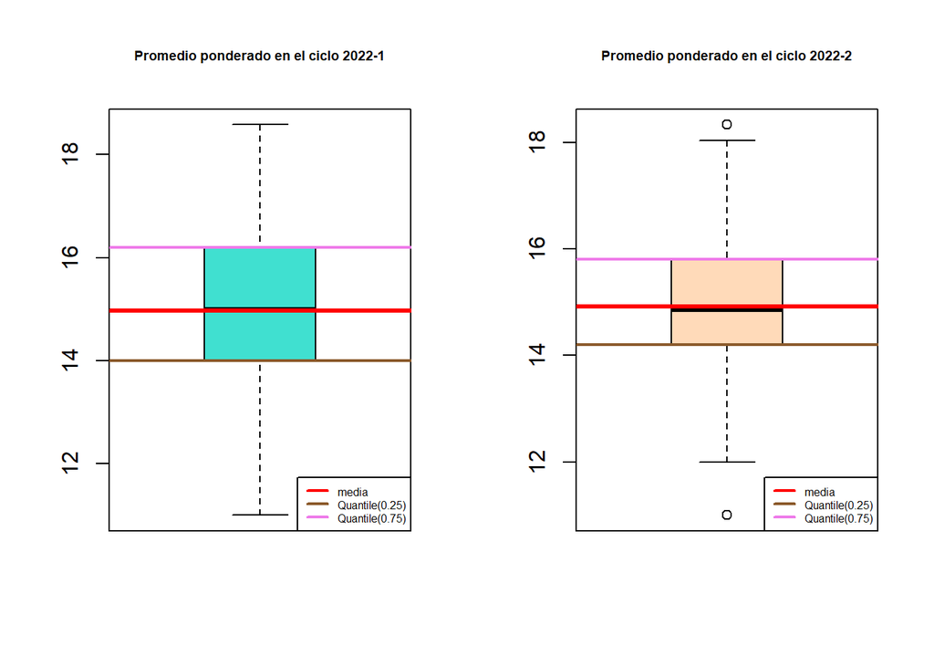

**Descriptores numéricos:**

**Ciclo 2022-1 y 2022-2:**

| Media | Mediana | Mínimo | Máximo | Desv_std | Q1 | Q3 |
| --- | --- | --- | --- | --- | --- | --- |
| 14.97 | 15 | 11 | 18.58 | 1.5 | 14 | 16.2 |

| Media | Mediana | Mínimo | Máximo | Desv_std | Q1 | Q3 |
| --- | --- | --- | --- | --- | --- | --- |
| 14.92 | 14.85 | 11 | 18.33 | 1.21 | 14.2 | 15.8 |

Según las gráficas, podemos afirmar que los promedios ponderados de los estudiantes en ambos ciclos no ha variado significativamente. Además, el rango intercuartílico en ambos ciclos nos indica que alrededor del 50% de los datos centrales se encuentran entre 14 y 16 aproximadamente. Por último, mencionar que debido a la desviación estándar en ambos casos nos muestra que los promedios de los alumnos tienden a la media obtenida.

### 2.1.2 *ACTIVIDAD FÍSICA*

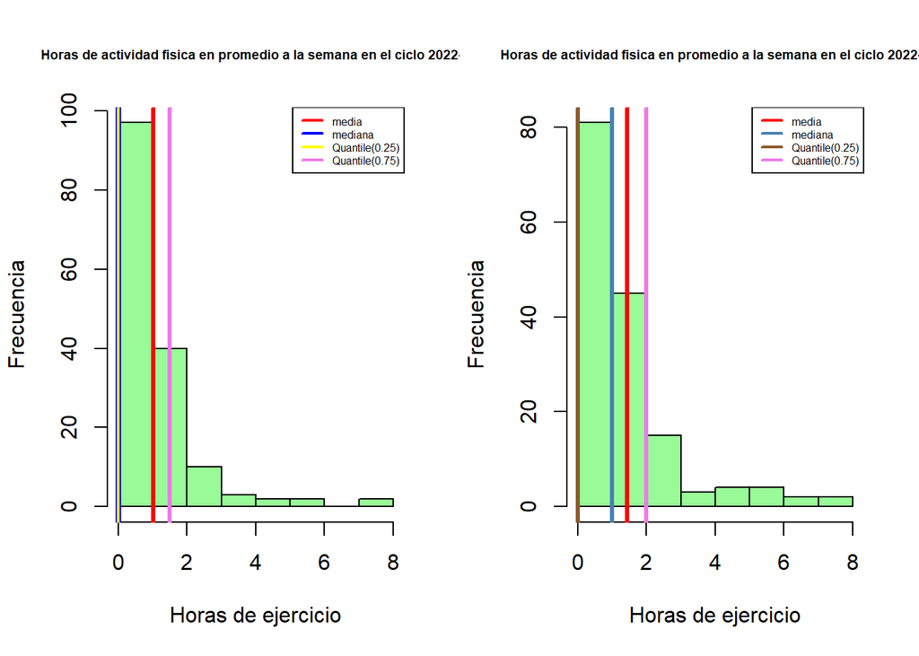

**Descriptores numéricos:**

**Ciclo 2022-1 y 2022-2:**

| Media | Mediana | Mínimo | Máximo | Desv_std | Q1 | Q3 |
| --- | --- | --- | --- | --- | --- | --- |
| 1.02 | 0 | 0 | 8 | 1.45 | 0 | 1.5 |

| Media | Mediana | Mínimo | Máximo | Desv_std | Q1 | Q3 |
| --- | --- | --- | --- | --- | --- | --- |
| 1.42 | 1 | 0 | 8 | 1.68 | 0 | 2 |

Respecto a estas dos gráficas podemos concluir lo siguiente: en comparación al ciclo 2022-1, hubo un incremento en los estudiantes que sí realizan ejercicio físico en el ciclo 2022-2 y disminuyó el número de estudiantes que no hacían actividad física. Una de las muchas formas de comprobar esto es en la cantidad de horas promedio de ejercicio, en el caso del ciclo 2022-1 fue de 1.02, mientras que en el 2022-2 este número aumentó a 1.42.

### 2.1.3 *HORAS DE SUEÑO*

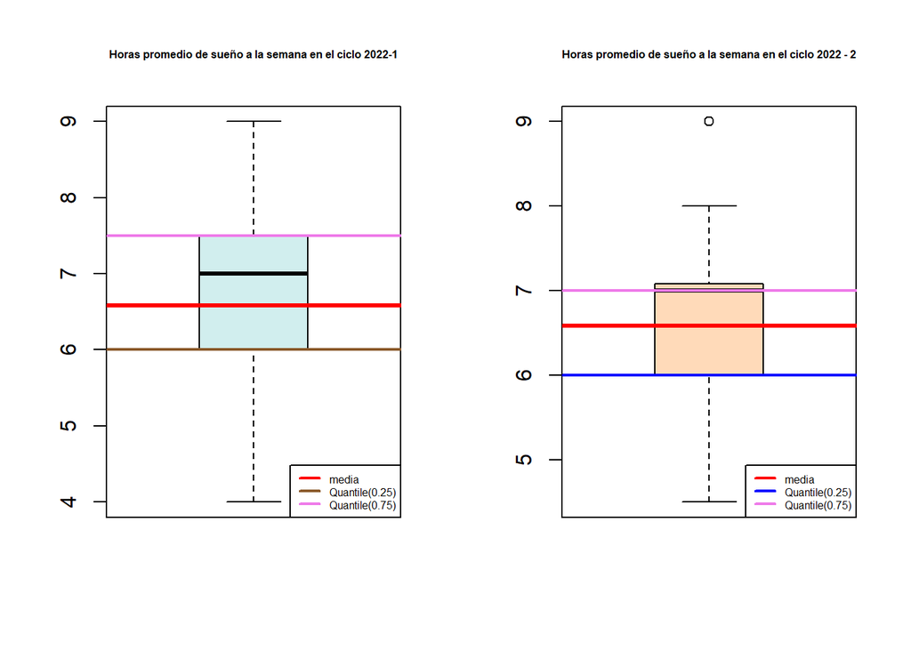

**Descriptores numéricos:**

**Ciclo 2022-1 y 2022-2:**

| Media | Mediana | Mínimo | Máximo | Desv_std | Q1 | Q3 |
| --- | --- | --- | --- | --- | --- | --- |
| 6.58 | 7 | 4 | 9 | 1.03 | 6 | 7.5 |

| Media | Mediana | Mínimo | Máximo | Desv_std | Q1 | Q3 |
| --- | --- | --- | --- | --- | --- | --- |
| 6.59 | 7 | 4.5 | 9 | 0.88 | 6 | 7 |

### 2.1.4 *IMC*

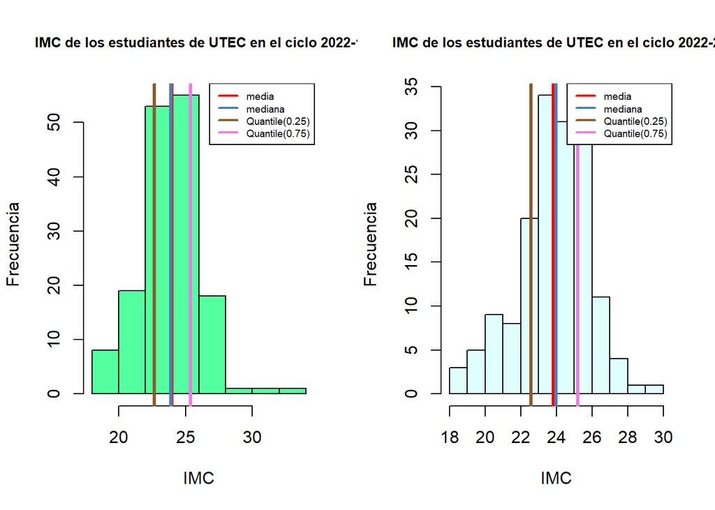

**Descriptores numéricos:**

**Ciclo 2022-1 y 2022-2:**

| Media | Mediana | Mínimo | Máximo | Desv_std | Q1 | Q3 |
| --- | --- | --- | --- | --- | --- | --- |
| 23.93 | 23.88 | 18.17 | 33.11 | 2.25 | 22.67 | 25.35 |

| Media | Mediana | Mínimo | Máximo | Desv_std | Q1 | Q3 |
| --- | --- | --- | --- | --- | --- | --- |
| 23.84 | 23.98 | 18.51 | 29.97 | 2.04 | 22.58 | 25.21 |

Sobre el IMC de los estudiantes podemos afirmar que según la gráfica el promedio de IMC en ambos ciclos ha variado ligeramente. Comparando ambas gráfica y realizando un análisis de los datos, podemos concluir que en comparación al ciclo 2022-1, el número de alumnos con un IMC saludable aumentó de 98 a 104 en 2022-2.

## 2.2 *VARIABLE CUALITATIVA*

### 2.2.1 *HÁBITOS ALIMENTICIOS*

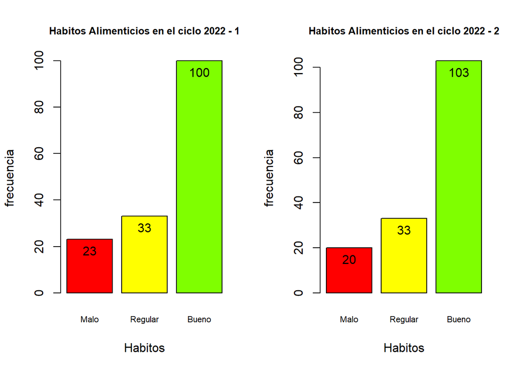

**Ciclo 2022-1 y 2022-2:**

| Quantile_64 |
| --- |
| Bueno |

| Quantile_66 |
| --- |
| Bueno |

# 3 **ANÁLISIS DESCRIPTIVO BIVARIADO**

### 3.0.1 *Objetivo 1*

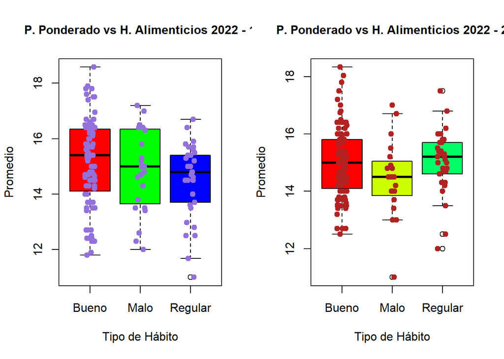

*Para llegar a una conclusión, compararemos ambas gráficas. En el hábito alimenticio bueno, disminuyó la mediana de los promedios ponderados, por lo que podemos inferir que hubo alumnos que al mejorar sus hábitos bajaron su promedio ponderado o de que hubo alumnos que tuvieron buen promedio ponderado, pero sus hábitos alimenticios cambiaron a regular o malo y como consecuencia bajo la mediana de promedios ponderados en el hábito alimenticio bueno. En el hábito alimenticio regular, se puede ver claramente que la mediana aumentó, por lo que se infiere que hubo alumnos que al cambiar sus hábitos alimenticios a regular mantuvieron o mejoraron sus promedios ponderados. En el hábito alimenticio malo, se puede ver claramente que su mediana es baja, por lo que se infiere que al tener un mal hábito alimenticio bajaron su promedio ponderado final.* *En conclusión, existe una ligera relación entre los hábitos alimenticios y los promedios ponderados que los estudiantes de UTEC presentaron en nuestro estudio.*

### 3.0.2 *Objetivo 3*

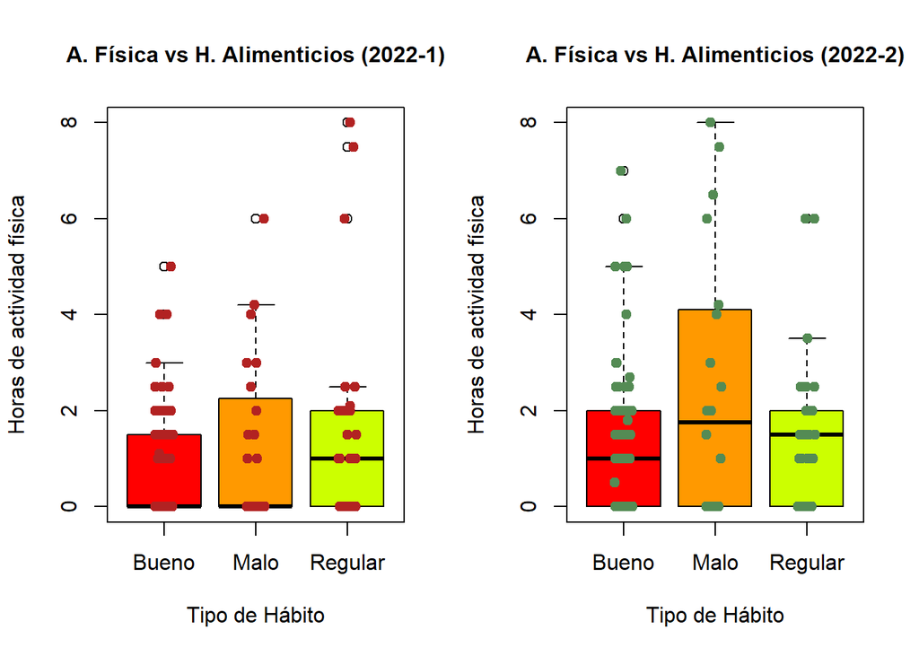

### 3.0.3 *Objetivo 6*

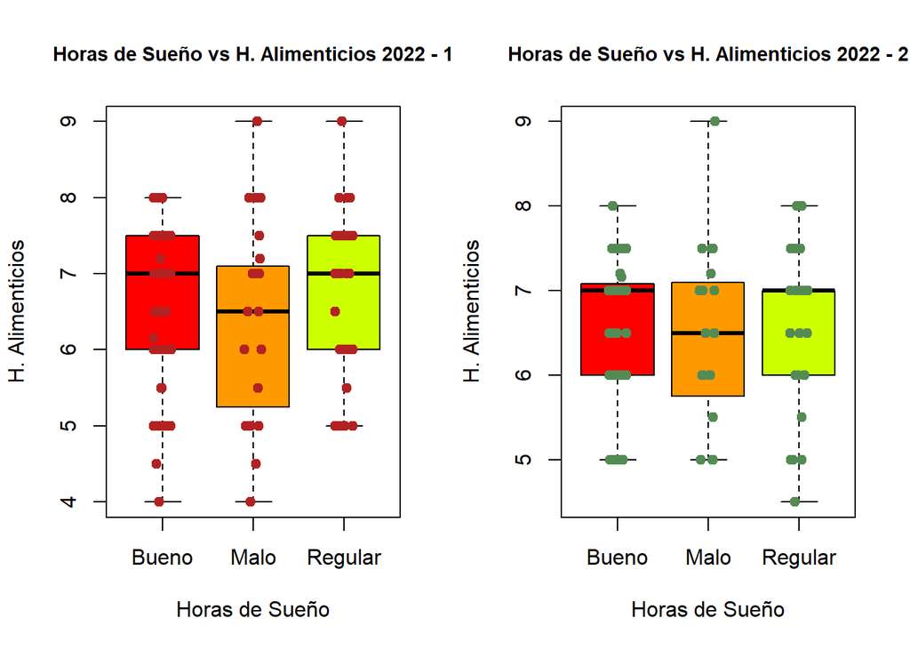

# 4 **ANÁLISIS PROBABILÍSTICO**

**TABLA 1**

La siguiente tabla representa la cantidad de alumnos que hizo actividad física de acuerdo al hábito alimenticio que presento en el ciclo 2022-1.

|  | 0 | 1 | 1.1 | 1.5 | 2 | 2.1 | 2.5 | 3 | 4 | 4.2 | 5 | 6 | 7.5 | 8 |
| --- | --- | --- | --- | --- | --- | --- | --- | --- | --- | --- | --- | --- | --- | --- |
| Bueno | 57 | 7 | 1 | 15 | 13 | 0 | 3 | 1 | 2 | 0 | 1 | 0 | 0 | 0 |
| Malo | 12 | 2 | 0 | 2 | 1 | 0 | 1 | 2 | 1 | 1 | 0 | 1 | 0 | 0 |
| Regular | 13 | 6 | 0 | 2 | 6 | 1 | 2 | 0 | 0 | 0 | 0 | 1 | 1 | 1 |

## 4.1 **PROBABILIDAD EMPÍRICA**

### 4.1.1 *HÁBITOS ALIMENTICIOS*

**Experimento:** Seleccionar al azar a un estudiante y observar el tipo de hábito alimenticio que tuvo dentro de nuestro estudio que tiene un total de 156 muestras.

**Ω = { Bueno, Regular, Malo }**

Se definen los siguientes eventos atómicos:

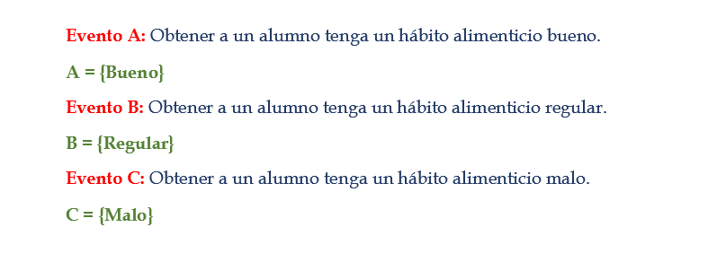

**EJEMPLO:**

- ¿Cuál es la probabilidad de que un alumno de UTEC tenga un hábito alimenticio bueno?

  $$\mathbb{P}(A)=\frac{n(A)}{n(Ω)}$$

La probabilidad de que un alumno de UTEC tenga un hábito alimenticio bueno es de 0.64

- ¿Cuál es la probabilidad de que un alumno de UTEC tenga un hábito alimenticio regular?

  $$\mathbb{P}(B)=\frac{n(B)}{n(Ω)}$$

La probabilidad de que un alumno de UTEC tenga un hábito alimenticio regular es de 0.21

- ¿Cuál es la probabilidad de que un alumno de UTEC tenga un hábito alimenticio malo?

  $$\mathbb{P}(C)=\frac{n(C)}{n(Ω)}$$

La probabilidad de que un alumno de UTEC tenga un hábito alimenticio malo es de 0.15 .

### 4.1.2 *HORAS PROMEDIO DE ACTIVIDAD FÍSICA*

**Experimento:** Seleccionar al azar a un estudiante y observar la cantidad de horas de actividad física que realizaron los estudiantes dentro de nuestro estudio el cual tiene un total de 156 muestras.

**Ω = { 0, 1, 1.1, 1.5, 2, 2.1, 2.5, 3, 4, 4.2, 5, 6, 7.5, 8 }**

Se definen los siguientes eventos atómicos:

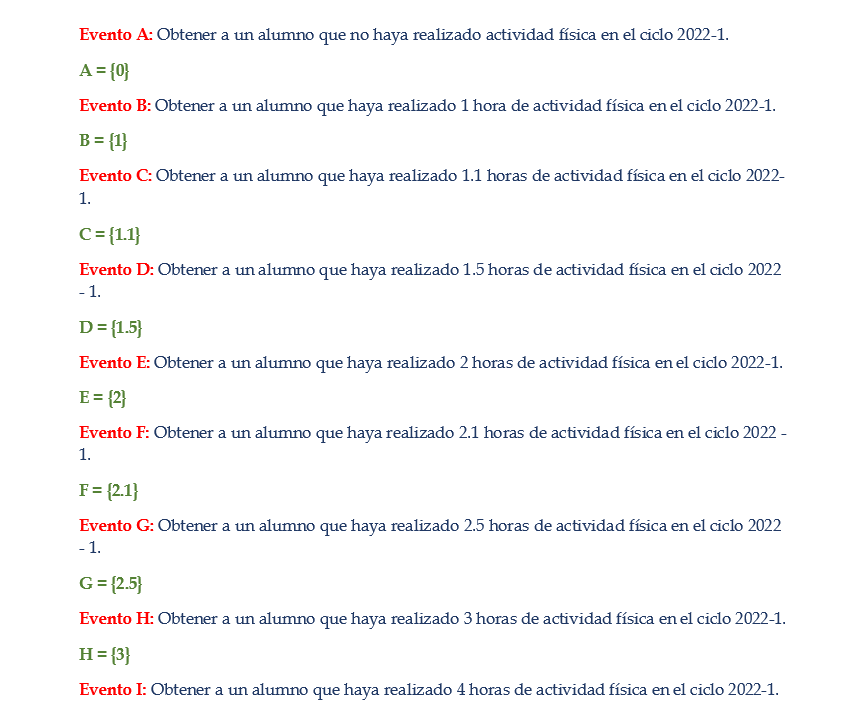

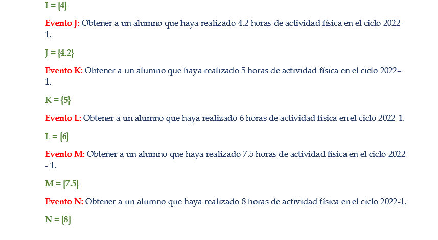

**EJEMPLO**

- ¿Cuál es la probabilidad de que un alumno de UTEC no haya hecho ninguna actividad física?

  $$\mathbb{P}(A)=\frac{n(A)}{n(Ω)}$$

La probabilidad de que un alumno de UTEC no haya hecho ninguna actividad física es de 0.53 .

- ¿Cuál es la probabilidad de que un alumno de UTEC haya hecho una hora de actividad física?

  $$\mathbb{P}(B)=\frac{n(B)}{n(Ω)}$$

La probabilidad de que un alumno de UTEC haya hecho una hora de ecatividad física es de 0.1 .

- ¿Cuál es la probabilidad de que un alumno de UTEC haya hecho tres horas de actividad física?

  $$\mathbb{P}(H)=\frac{n(H)}{n(Ω)}$$

La probabilidad de que un alumno de UTEC haya hecho tres horas de actividad física es de 0.02 .

## 4.2 **PROBABILIDAD CONDICIONAL**

### 4.2.1 *PROBABILIDAD 1*

Los universitarios hoy en día, en su mayoría, descuidamos nuestra alimentación por el poco tiempo que tenemos o por las diferentes actividades que realizamos. Ya sea ir al gimnasio, realizar ciertas actividades de la casa, etc. Entonces, ¿cuál es la probabilidad de que un alumno de UTEC tenga un hábito alimenticio malo dado que no realice actividad física?

Se definen los eventos:

**A:** Seleccionar a un alumno con hábito alimenticio malo.

**B:** Seleccionar a un alumno que no realizo actividad física.

- Primero, se determinará si los eventos *A* y *B* son dependientes o independientes.

  $$\mathbb{P}(A \cap B)=\mathbb{P}(A) *
  \mathbb{P}(B)$$

$\mathbb{P}(A \cap B)$

```
## [1] 0.077
```

$\mathbb{P}(A) * \mathbb{P}(B)$

```
## [1] 0.077
```

Según los resultados obtenidos se puede observar que ambos eventos son independientes. Es decir, la probabilidad de que un alumno de UTEC tenga un hábito alimenticio malo no está influenciada por la probabilidad de que no realicé alguna actividad física.

- Segundo, respondemos a la pregunta haciendo uso de la probabilidad condicional.

$$\mathbb{P}(A/B)=\frac{\mathbb{P}(A\cap
B)}{\mathbb{P}(B)}$$

La probabilidad de que un alumno de UTEC tenga un hábito alimenticio malo dado que no realice ninguna actividad física es de 0.15 . Como los eventos son independientes, se cumple que P(A/B)=P(A). Si revisamos en la parte de probabilidad empírica, la probabilidad de que un alumno tenga un hábito alimenticio malo es igual a la hallada aquí. Por lo que se puede determinar que ambos eventos son independientes.

- Tercero, mediante el teorema de Bayes para hallar la probabilidad de que un alumno no haya hecho ningún tipo de actividad física dado que tenga un hábito alimenticio malo (${P}(B/A)$).

$$\mathbb{P}(B|A)=\frac{{P}(B)*P(A|B)}{P(A)}$$

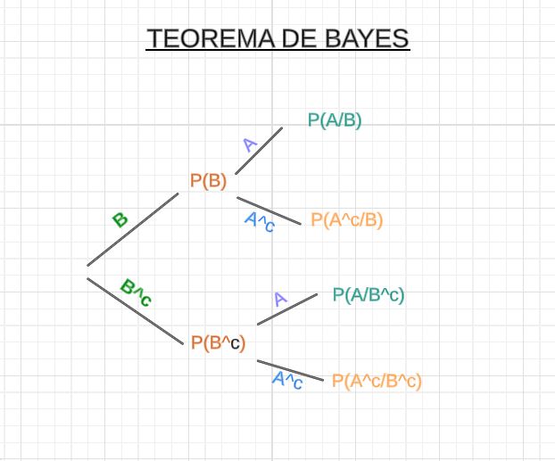

Eventos:

**A:** Obtener un alumno con hábito alimenticio malo.

**B:** Obtener un alumno que no haya hecho ningún tipo de actividad física.

- Probabilidad total.

$$\mathbb{P}(A)={P}(B)*P(A/B) +
{P}(B^c)*P(A/B^c)$$

La probabilidad total(P(A)) es: 0.15

- Resultado.

La probabilidad de que un alumno de UTEC no realice ninguna actividad física dado que su hábito alimenticio sea malo es de 0.53 . Como los eventos son independientes, se cumple que P(B/A)=P(B). Si revisamos en la parte de probabilidad empírica, la probabilidad de que un alumno no realicé actividad física es igual a la hallada aquí. Por lo que se puede determinar que ambos eventos son independientes.

### 4.2.2 *PROBABILIDAD 2*

**¿Cuál es la probabilidad de que un alumno tenga un buen hábito alimenticio dado que hizo actividad física como máximo 2 horas?**

Eventos:

**A:** Obtener a un alumno con hábito alimenticio bueno.

**B:** Obtener a un alumno que haya hecho como máximo 2 horas de actividad física.

- Primero se determinara si los eventos presentados son dependientes o independientes.

$\mathbb{P}(A \cap B)$

```
## [1] 0.596
```

$\mathbb{P}(A) * \mathbb{P}(B)$

```
## [1] 0.563
```

Según los resultados obtenidos, se puede observar que ambos resultados son diferentes y por ende son dependientes. En otras palabras, la probabilidad de que un alumno tenga un buen hábito alimenticio bueno influye en la probabilidad de que haga hecho ejercicio como máximo 2 horas.

- Segundo, respondemos a la pregunta haciendo uso de la probabilidad condicional.

- Tercero, mediante el teorema de Bayes en el que se hallará la probabilidad de que un alumno haya realizado como máximo 2 horas de actividad física dado que tuvo un hábito alimenticio bueno.

$$\mathbb{P}(B|A)=\frac{{P}(B)*P(A|B)}{P(A)}$$

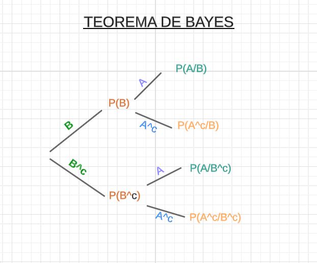

**A:** Obtener un alumno con hábito alimenticio bueno.

**B:** Obtener un alumno que haya hecho como máximo dos horas de actividad física.

- Probabilidad total:

$$\mathbb{P}(A)={P}(B)*P(A/B) +
{P}(B^c)*P(A/B^c)$$

```
## La probabilidad total(P(A)) es: 0.64
```

- Resultado.

La probabilidad de que un alumno realizado como máximo dos horas de actividad física y dado que tenga un buen hábito alimenticio es de: 0.93

## 4.3 **VARIABLES ALEATORIAS DISCRETAS**

El siguiente análisis se hará en función a las variables que fueron presentadas a lo largo de nuestro proyecto, en esta parte utilizaremos algunas de ellas para analizar la posibilidad de ocurrencia de cada evento que se va a plantear. A raíz de ello, utilizaremos la distribución binomial y la distribución geométrica.

### 4.3.1 *Distribución Binomial*

El experimento binomial estará hecho en base a la variable Hábitos Alimenticios.

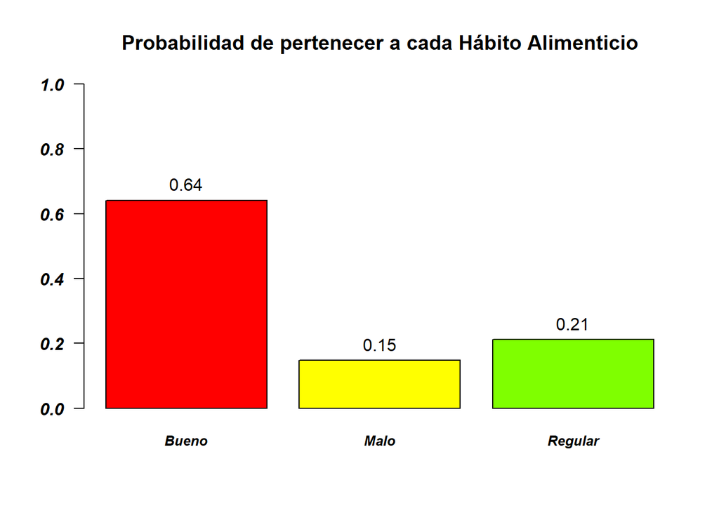

**Éxito:** Encontrar a los estudiantes con hábito alimenticio **Bueno**.

*VARIABLE ALEATORIA DISCRETA:*

**X:** Número de alumnos de UTEC que tienen un hábito alimenticio **Bueno** dentro del estudio que se realizo a 156 estudiantes.

*PARÁMETROS de X~Bin(n,p):*

**p:** Probabilidad de éxito**(P(E))**.

**n:** Número total de alumnos de nuestro estudio realizado.

#### 4.3.1.1 **Gráfica**

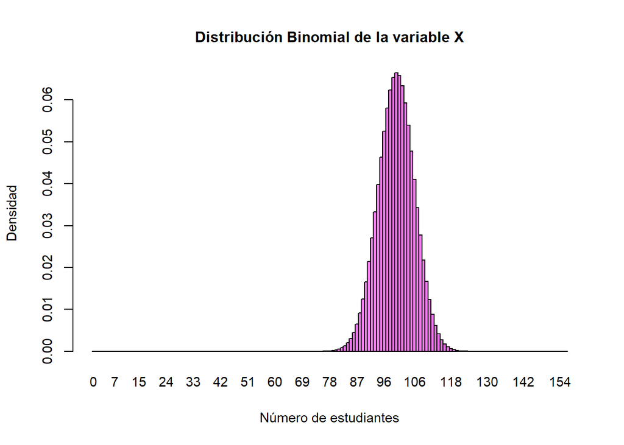

#### 4.3.1.2 *PROPIEDADES:*

**ESPERANZA(E(x))**

```
## Valor esperado es: 100
```

**Varianza(Var(x))**

```
## La varianza es: 35.9
```

**DESVIACIÓN ESTÁNDAR**

```
## La desviación es: 5.99
```

#### 4.3.1.3 *PROBLEMA*

UTEC realiza una reunión general acerca de como tener una vida saludable. A la reunión acuden un total de 156 estudiantes con diferentes tipos de hábitos alimenticios cada uno. Un nutricionista que observaba de lejos, quiere conocer la probabilidad de que por lo menos 100 alumnos tengan un hábito alimenticio bueno.

**X :** Número de alumnos de la Universidad de Ingeniería y Tecnología que tienen un hábito alimenticio **Bueno** dentro del estudio que se realizo a 156 estudiantes.

*RESULTADO*

**P(X>=100):**

```
## La probabilidad de que por lo menos 100 alumnos de la reunión tengan un hábito alimenticio bueno es de:  0.53
```

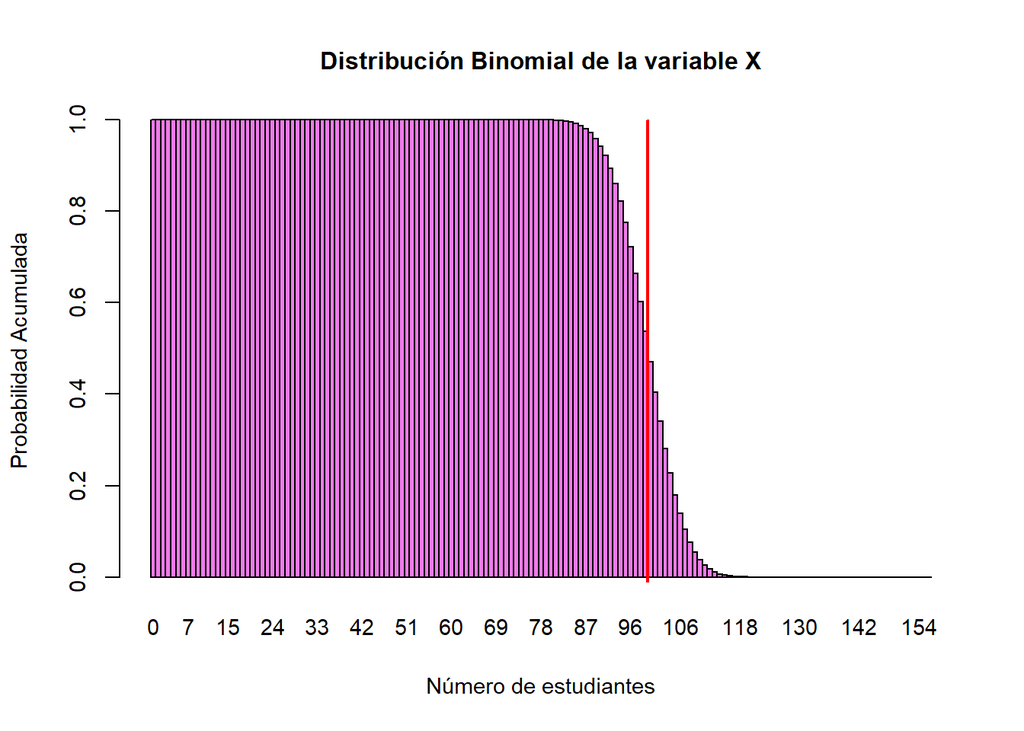

### 4.3.2 *Distribución Geométrica*

El experimento Geométrico estará hecho en base a la variable cantidad de veces que comía en el día **(Comida1)**.

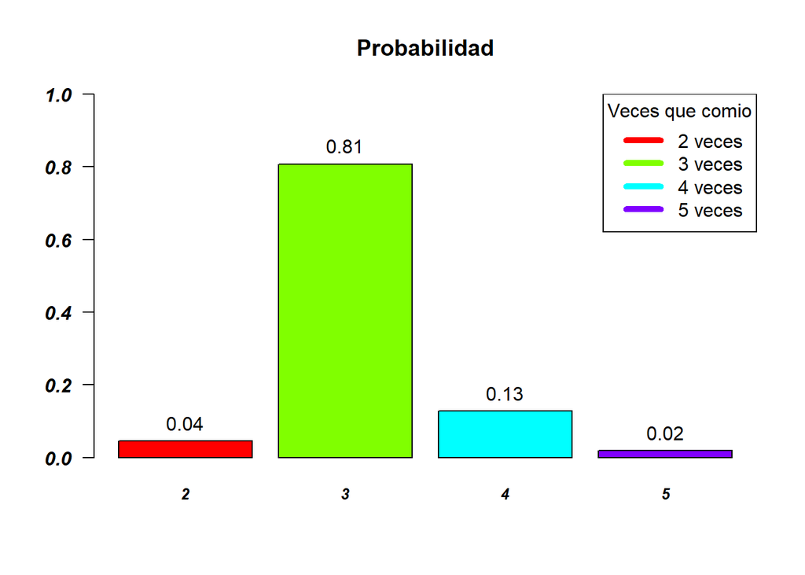

**Éxito:** Encontrar a un estudiante que comió 4 veces al día.

**Fracaso:** Encontrar a un estudiante que no haya comido 4 veces al día.

*VARIABLE ALEATORIA DISCRETA:*

**X:** Número de encuestas realizadas hasta encontrar a un estudiante que haya comido 4 veces al día dentro de una muestra de 156 observaciones pertenecientes a UTEC.

*Parámetros de X~Geom(p):*

**p:** Probabilidad de éxito**(P(E))**.

#### 4.3.2.1 *Gráfica*

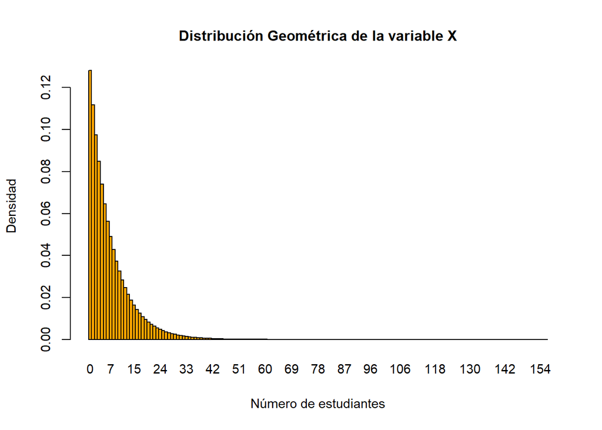

#### 4.3.2.2 *PROPIEDADES:*

**ESPERANZA(E(x))**

```
## Valor esperado es: 7.8
```

**Varianza(Var(x))**

```
## La varianza es: 53.04
```

**DESVIACIÓN ESTÁNDAR**

```
## La desviación estándar es: 7.28
```

#### 4.3.2.3 *PROBLEMA*

En una base datos que está compuesta por un total de 156 observaciones pertenecientes a un estudio del curso de estadística y probabilidades de UTEC, un investigador identifico de que una de las variables de dicha base trataba sobre la cantidad de veces que un alumno comía al día. Este se preguntó, así mismo, que probabilidad habría si de las 156 observaciones tomamos 20 y la observación 20 sea un estudiante que haya comido 4 veces al día.

**X:** Número de estudiantes que no hayan comido 4 veces al día hasta encontrar al estudiante que si comió 4 veces al día dentro de una muestra de 156 observaciones pertenecientes a UTEC.

*RESULTADO*

**P(X=19)**

```
## La probabilidad de que si de las 20 observaciones escogidas, la observación 20 sea de un alumno que haya comido 4 veces al día es de:  0.0095
```

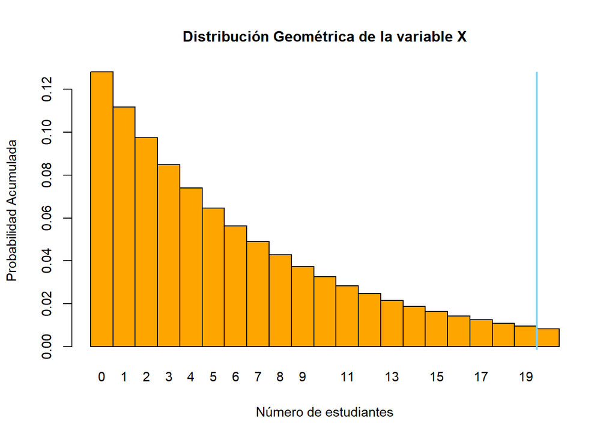

## 4.4 **VARIABLES ALEATORIAS CONTINUAS**

### 4.4.1 *DISTRIBUCIÓN NORMAL*

En este caso trabajaremos con el Índice de masa corporal de los estudiantes en el ciclo 2022-1 **(IMC1)**.

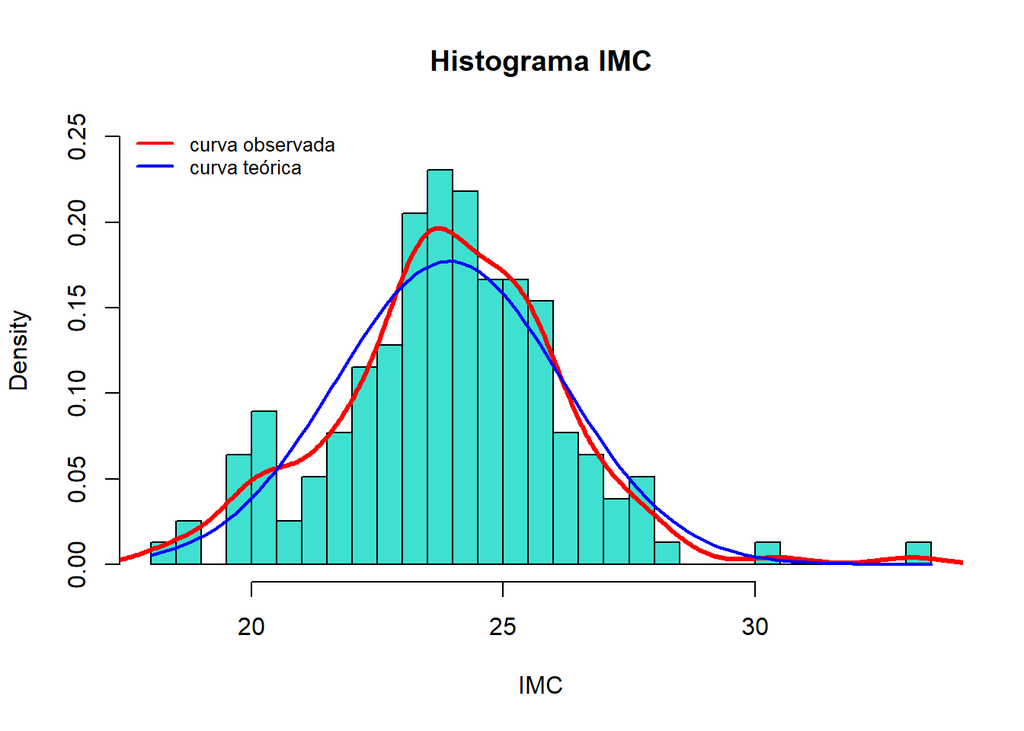

Como podemos ver en el siguiente gráfico de densidad, aparenta tener una densidad normal pero eso lo comprobaremos al comparar la media con la mediana.

#### 4.4.1.1 *PROPIEDADES*

*Media:*

```
## La media es: 23.93
```

*Mediana:*

```
## La mediana es: 23.88
```

Como se pueda observar, ambos valores obtenidos son aproximadamente iguales **(Media ≈ Mediana)** por lo que se puede decir que la distribución normal es simétrica.

En segundo lugar, vamos a evaluar la varianza**(Var)** y su desviación estándar**(Sd)**, para ello utilizaremos la siguiente notación: $V=S^2$

*VARIANZA:*

```
## La varianza es:  5.0664
```

*DESVIACIÓN ESTÁNDAR:*

[output not shown]

*ESPERANZA:*

```
## La esperanza obtenida es: 23.93
```

#### 4.4.1.2 *Parámetros de X~N(µ,σ):*

**µ:** Promedio promedio de nuestra variable elegida**(IMC1)**

**σ:** Desviación estándar de nuestra variable elegida**(IMC1)**

#### 4.4.1.3 **EJEMPLO**

En una encuesta realizada a 156 estudiantes, se recopiló el peso y la talla con el fin de que un investigador pueda determinar si su peso y su talla se encuentren correctamente equilibrados. Para ello, el investigador calcula el IMC de cada estudiante y decide empezar a elegir al azar a los estudiantes presentes ahí. Entonces, ¿cuál es la probabilidad de que al elegir a un estudiante este tenga un IMC alto? **(IMC mayor a 25)**?

*VARIABLE ALEATORIA CONTINUA:*

**X:** El IMC de los estudiantes que realizaron la encuesta.

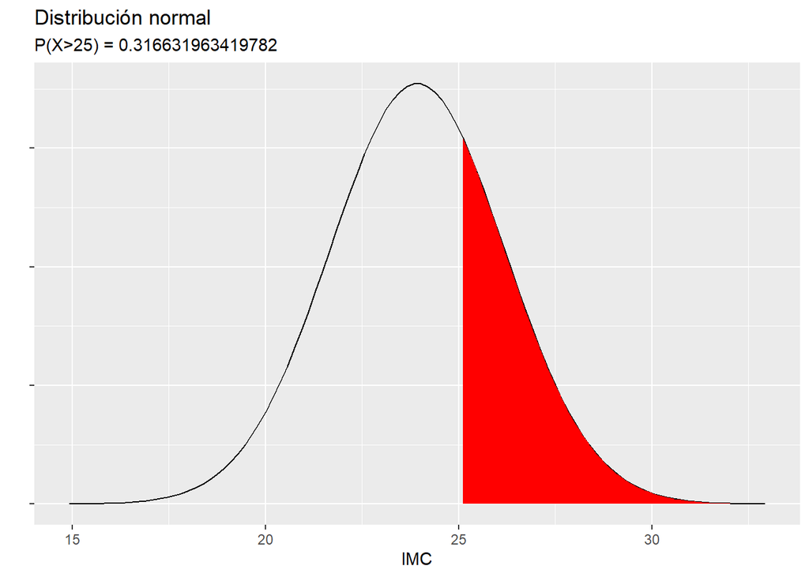

**Resultado:** La probabilidad de que el investigador elija al azar a un estudiante con IMC alto es de 0.32, esto significaría (en este caso) que sería un IMC que significa el investigador estaría buscando estudiantes con sobrepeso u obesidad.

### 4.4.2 *DISTRIBUCIÓN EXPONENCIAL*

En este caso trabajaremos con la cantidad de horas de actividad física que los estudiantes hicieron en el ciclo 2022-1 **(Actifis1)**.

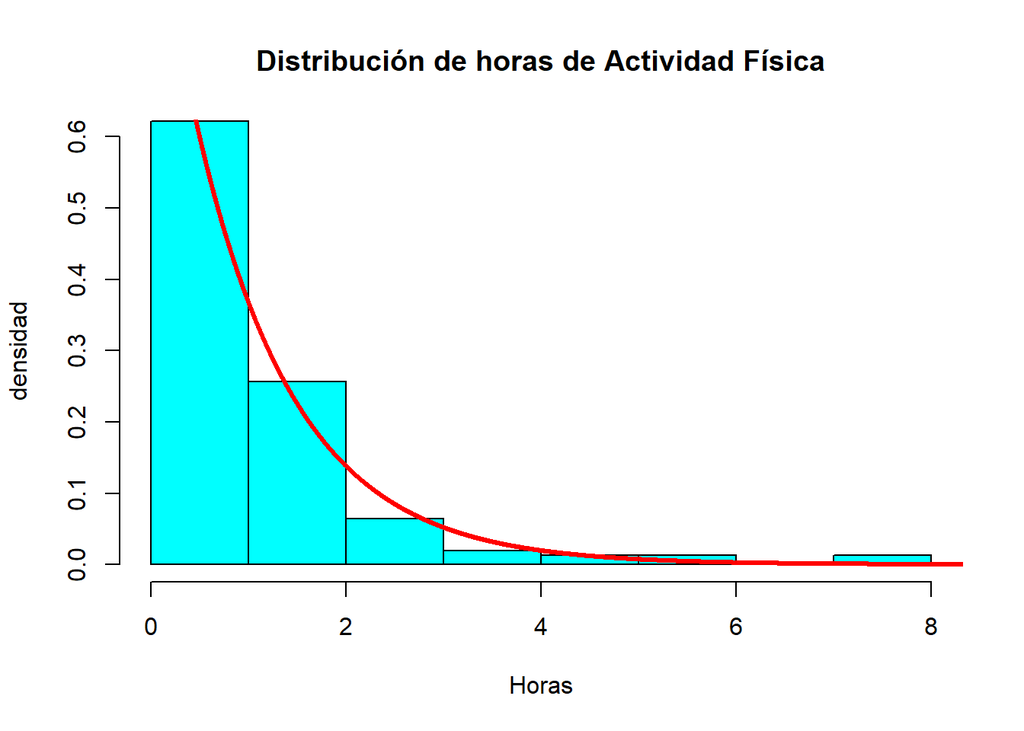

#### 4.4.2.1 *PROPIEDADES*

*ESPERANZA-FORMULA:*

```
## El valor esperado es:  1.02
```

*ESPERANZA-TEÓRICA*

```
## El valor esperado es:  1.02
```

*VARIANZA-FORMULA:*

```
## La varianza es:  2.12
```

*VARIANZA-TEÓRICA*

```
## La varianza es:  1.04
```

Según los resultados obtenidos al aplicar las propiedades, se puede observar que la esperanza es igual, pero difieren en su varianza. Se considera que es una distribución exponencial por el hecho de que a mayor cantidad de horas menos cantidad de personas se encuentra en la distribución. Además, cumple el estándar de ser positivo y tener forma exponencial.

#### 4.4.2.2 *Parámetros de X~exp(λ)*

**λ:** Es la tasa promedio, de nuestra variable aleatoria continua en el que ocurre el evento.

#### 4.4.2.3 *EJEMPLO*

**X:** Cantidad de horas de actividad física.

$$P(X>3)$$

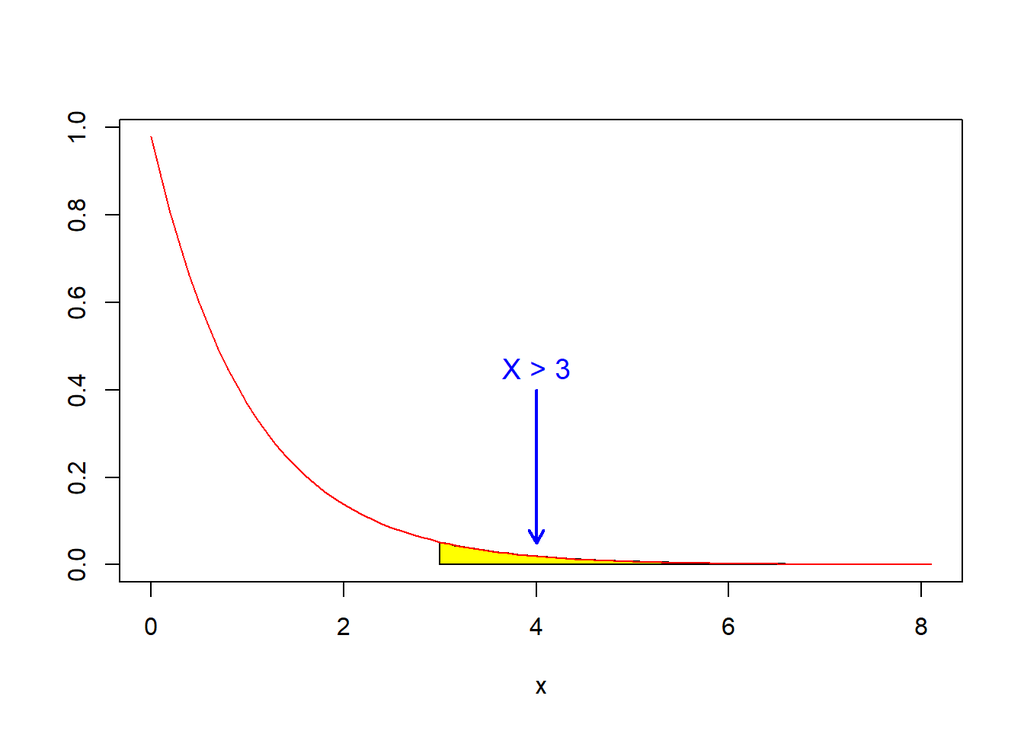